# Please add a more descriptive title

Sarah Urbut

2017-05-30

In this notebook, we make the metaplots comparing the original effect estimates (*effects of what?*), and the posterior estimates obtained using the multivariate adaptive shrinkage model. *What is the main result(s) we are showing in this notebook? What is the point of showing these plots.* The plots below were used to create Fig. 4 of the paper.

First, we load the necessary packages into the R environment.

```r
library(rmeta)
```

*Please explain here what this next code chunk does. It looks like it is reading a bunch of data files. What data are being loaded?*

```r
source("../Scripts/normfuncs.R")

z.stat         <- read.table("../Data/maxz.txt")
b.stat         <- read.table("../Data/maxbetahats.txt")
standard.error <- b.stat/z.stat

covmat          <- readRDS("../Data_vhat/covmatwithvhat.rds")
posterior.means <- read.table("../Data_vhat/withvhatposterior.means.txt")[,-1]
lfsr            <- read.table("../Data_vhat/withvhatlfsr.txt")[,-1]
mar.var         <- read.table("../Data_vhat/withvhatmarginal.var.txt")[,-1]
colnames(lfsr)  <- colnames(mar.var) <-
  colnames(posterior.means) <-
  colnames(z.stat)

posterior.betas <- standard.error * posterior.means
pm.beta.norm    <- het.norm(posterior.betas)

missing.tissues <- c(7,8,19,20,24,25,31,34,37)
uk3labels       <- read.table("../Data/uk3rowindices.txt")[,1]
```

*In this next chunk you are defining a function. Can you briefly explain in 1-2 sentences what this function does, and how you will use it in the code chunks below?*

```r
# Can you please give a better name to this function than "newfunc.2"?
# Maybe a name like gen.metaplot?
newfunc.2 <- function (j) {
  gtex.colors <- read.table('../Data/GTExColors.txt', sep = '\t',
                            comment.char = '')[-missing.tissues,2]
  gtex.colors <- gtex.colors[uk3labels]

  pm.beta.norm  <- pm.beta.norm[,uk3labels] # Shuffle columns.
  z.shuffle     <- z.stat[,uk3labels]
  b.shuffle     <- b.stat[,uk3labels]
  post.var      <- mar.var[uk3labels]
  post.bshuffle <- posterior.betas[,uk3labels]
  sem.shuffle   <- standard.error[,uk3labels]
  lfsr          <- lfsr[,uk3labels]
  plot.title    <- strsplit(rownames(z.stat)[j], "[.]")[[1]][1]

  x <- as.numeric(post.bshuffle[j,])

  layout(t(1:2))

  metaplot(as.numeric(b.shuffle[j,]),as.numeric(sem.shuffle[j,]),xlab = "",
           ylab = "",colors = meta.colors(box = as.character(gtex.colors)),
           xlim = c(-1,1))
  title(plot.title)

  # Transform to posterior sd of beta.
  sd <- as.numeric(sem.shuffle[j,]) * sqrt(as.numeric(post.var[j,]))
  metaplot(x,sd,xlab = "",ylab = "",
           colors = meta.colors(box = as.character(gtex.colors)),
           xlim = c(-1,1))
  title(plot.title)
}
```

## First example: *MCPH1* gene

Our first example compares the *MCPH1* original eQTL estimates against the posterior estimates.

*What are the two plots showing? What is interesting about this example? What is the take-home message from this plot?*

*Please add labels to the horizontal and vertical axes. Which of these plots shows the original effect estimates, and which shows the posterior (“shrunk”) estimates?*

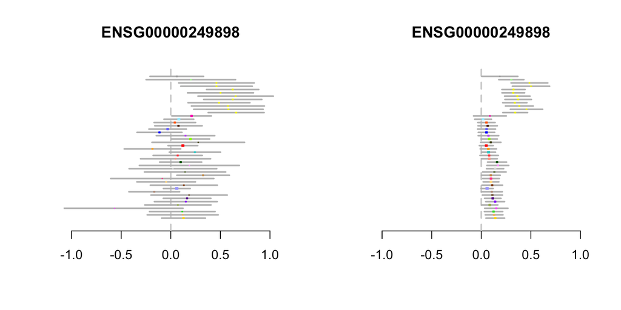

```r
three.ex.3 <-
  which(rownames(z.stat) == "ENSG00000249898.3_8_6521432_T_C_b37")
newfunc.2(three.ex.3)
```

```r
# This line of code doesn't seem to do anything. Why is it included?
whole.blood.spec <-
  which(rowSums(pm.beta.norm[,-44]<0.5)==43&(rowSums(lfsr[,1:44]<0.05)>=40))
```

## Second example: *FLJ13114* gene

*What is interesting about this example? What is the take-home message from this plot?*

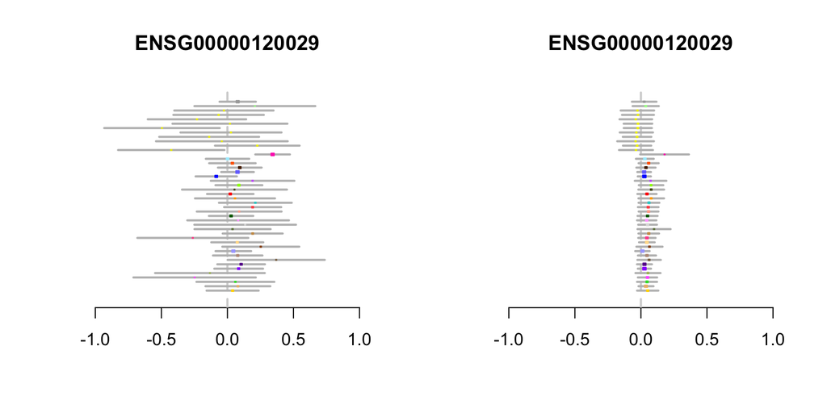

```r
five.ex <- which(rownames(z.stat) == "ENSG00000120029.8_10_103924251_G_A_b37")

# This line of code doesn't seem to do anything. Why is it included?
testes.spec <-  which(rowSums(pm.beta.norm[,-40]<0.5) == 43 &
                    (rowSums(lfsr[,1:44]<0.05)>=40))[1:10]

newfunc.2(five.ex)
```

## Third example: *RALBP1* gene

*What is interesting about this example? What is the take-home message from this plot?*

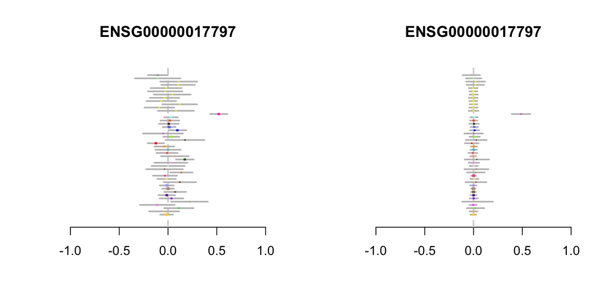

```r
wholebloodfour <-
  (which(rownames(z.stat) == "ENSG00000017797.7_18_9488704_C_T_b37"))
newfunc.2(wholebloodfour)
```

## Session Information

```r
print(sessionInfo())
# R version 3.4.0 (2017-04-21)
# Platform: x86_64-apple-darwin15.6.0 (64-bit)
# Running under: OS X El Capitan 10.11.6
#
# Matrix products: default
# BLAS: /Library/Frameworks/R.framework/Versions/3.4/Resources/lib/libRblas.0.dylib
# LAPACK: /Library/Frameworks/R.framework/Versions/3.4/Resources/lib/libRlapack.dylib
#
# locale:
# [1] en_US.UTF-8/en_US.UTF-8/en_US.UTF-8/C/en_US.UTF-8/en_US.UTF-8
#
# attached base packages:
# [1] grid      stats     graphics  grDevices utils     datasets  methods
# [8] base
#
# other attached packages:
# [1] rmeta_2.16
#
# loaded via a namespace (and not attached):
#  [1] compiler_3.4.0  backports_1.0.5 magrittr_1.5    rprojroot_1.2
#  [5] tools_3.4.0     htmltools_0.3.6 yaml_2.1.14     Rcpp_0.12.10
#  [9] stringi_1.1.5   rmarkdown_1.5   knitr_1.15.1    stringr_1.2.0
# [13] digest_0.6.12   evaluate_0.10
```